# TFM Notebook

Carga de los datos y librerias

```r
library("Hmisc")
```

```r
library(corrplot)
library(caret)
library(tidyverse)
library(ggplot2)
library(AppliedPredictiveModeling)
library(randomForest)
library(C50)
library(gbm)
library(caretEnsemble)
coimbra_data=read.csv(file = 'dataR2.csv')
head(coimbra_data)
```

|  | Age | BMI | Glucose | Insulin | HOMA | Leptin | Adiponectin | Resistin | MCP.1 | Classification |
| --- | --- | --- | --- | --- | --- | --- | --- | --- | --- | --- |
| 1 | 48 | 23.50000 | 70 | 2.707 | 0.4674087 | 8.8071 | 9.702400 | 7.99585 | 417.114 | 1 |
| 2 | 83 | 20.69049 | 92 | 3.115 | 0.7068973 | 8.8438 | 5.429285 | 4.06405 | 468.786 | 1 |
| 3 | 82 | 23.12467 | 91 | 4.498 | 1.0096511 | 17.9393 | 22.432040 | 9.27715 | 554.697 | 1 |
| 4 | 68 | 21.36752 | 77 | 3.226 | 0.6127249 | 9.8827 | 7.169560 | 12.76600 | 928.220 | 1 |
| 5 | 86 | 21.11111 | 92 | 3.549 | 0.8053864 | 6.6994 | 4.819240 | 10.57635 | 773.920 | 1 |
| 6 | 49 | 22.85446 | 92 | 3.226 | 0.7320869 | 6.8317 | 13.679750 | 10.31760 | 530.410 | 1 |

A continuación hacemos una exploración de los datos general

```r
summary(coimbra_data)
```

```
##       Age            BMI           Glucose          Insulin
##  Min.   :24.0   Min.   :18.37   Min.   : 60.00   Min.   : 2.432
##  1st Qu.:45.0   1st Qu.:22.97   1st Qu.: 85.75   1st Qu.: 4.359
##  Median :56.0   Median :27.66   Median : 92.00   Median : 5.925
##  Mean   :57.3   Mean   :27.58   Mean   : 97.79   Mean   :10.012
##  3rd Qu.:71.0   3rd Qu.:31.24   3rd Qu.:102.00   3rd Qu.:11.189
##  Max.   :89.0   Max.   :38.58   Max.   :201.00   Max.   :58.460
##       HOMA             Leptin        Adiponectin        Resistin
##  Min.   : 0.4674   Min.   : 4.311   Min.   : 1.656   Min.   : 3.210
##  1st Qu.: 0.9180   1st Qu.:12.314   1st Qu.: 5.474   1st Qu.: 6.882
##  Median : 1.3809   Median :20.271   Median : 8.353   Median :10.828
##  Mean   : 2.6950   Mean   :26.615   Mean   :10.181   Mean   :14.726
##  3rd Qu.: 2.8578   3rd Qu.:37.378   3rd Qu.:11.816   3rd Qu.:17.755
##  Max.   :25.0503   Max.   :90.280   Max.   :38.040   Max.   :82.100
##      MCP.1         Classification
##  Min.   :  45.84   Min.   :1.000
##  1st Qu.: 269.98   1st Qu.:1.000
##  Median : 471.32   Median :2.000
##  Mean   : 534.65   Mean   :1.552
##  3rd Qu.: 700.09   3rd Qu.:2.000
##  Max.   :1698.44   Max.   :2.000
```

```r
str(coimbra_data)
```

```
## 'data.frame':    116 obs. of  10 variables:
##  $ Age           : int  48 83 82 68 86 49 89 76 73 75 ...
##  $ BMI           : num  23.5 20.7 23.1 21.4 21.1 ...
##  $ Glucose       : int  70 92 91 77 92 92 77 118 97 83 ...
##  $ Insulin       : num  2.71 3.12 4.5 3.23 3.55 ...
##  $ HOMA          : num  0.467 0.707 1.01 0.613 0.805 ...
##  $ Leptin        : num  8.81 8.84 17.94 9.88 6.7 ...
##  $ Adiponectin   : num  9.7 5.43 22.43 7.17 4.82 ...
##  $ Resistin      : num  8 4.06 9.28 12.77 10.58 ...
##  $ MCP.1         : num  417 469 555 928 774 ...
##  $ Classification: int  1 1 1 1 1 1 1 1 1 1 ...
```

```r
table(coimbra_data$Classification)
```

```
##
##  1  2
## 52 64
```

Estudiamos y graficamos la distribución de los datos con respecto a la variable objetivo

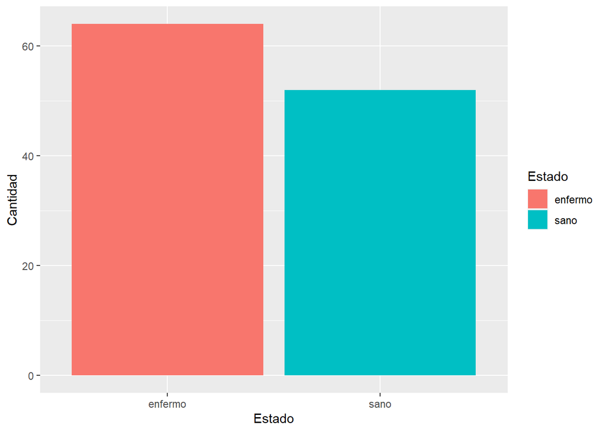

```r
coimbra_bar<-coimbra_data
coimbra_bar$Classification=unlist(lapply(coimbra_bar$Classification, function(x) ifelse(x==1,'sano','enfermo') ))
g <- ggplot(coimbra_bar, aes(Classification, fill=Classification))+ labs(
                      y="Cantidad", x = "Estado",fill = "Estado")
# Number of cars in each class:
g + geom_bar()
```

Graficamos valores extremos

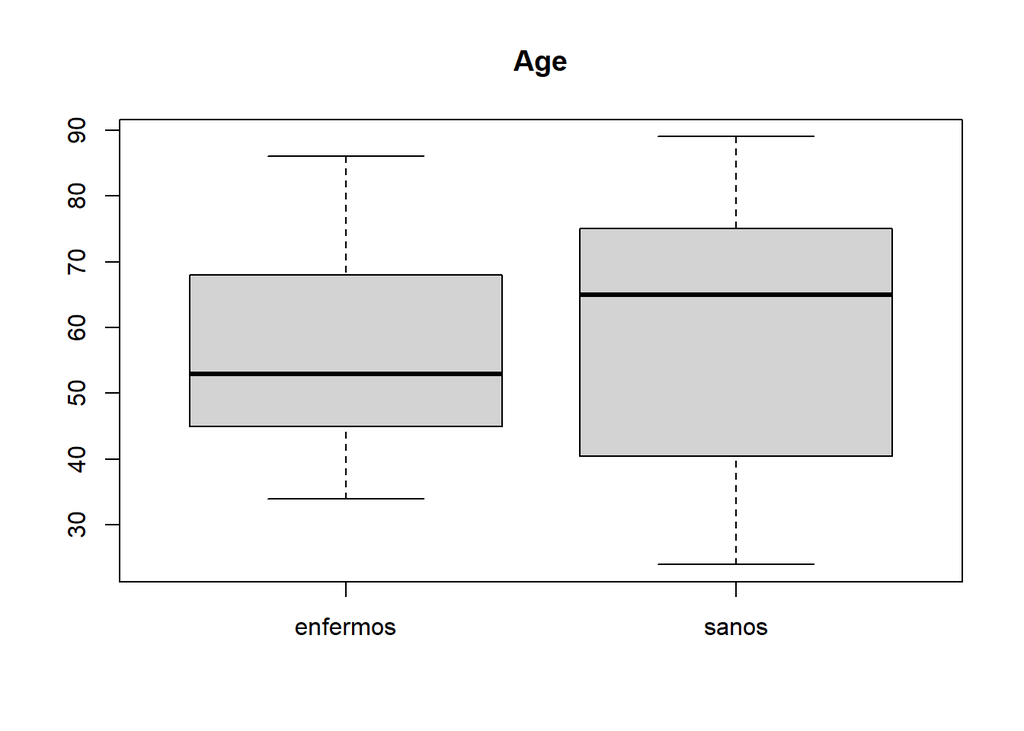

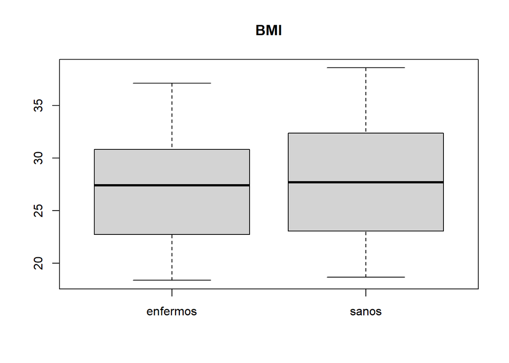

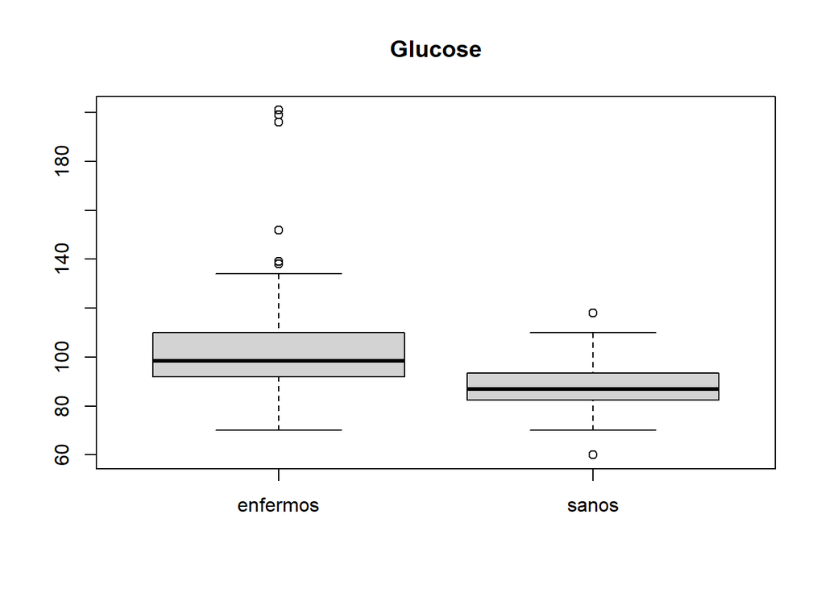

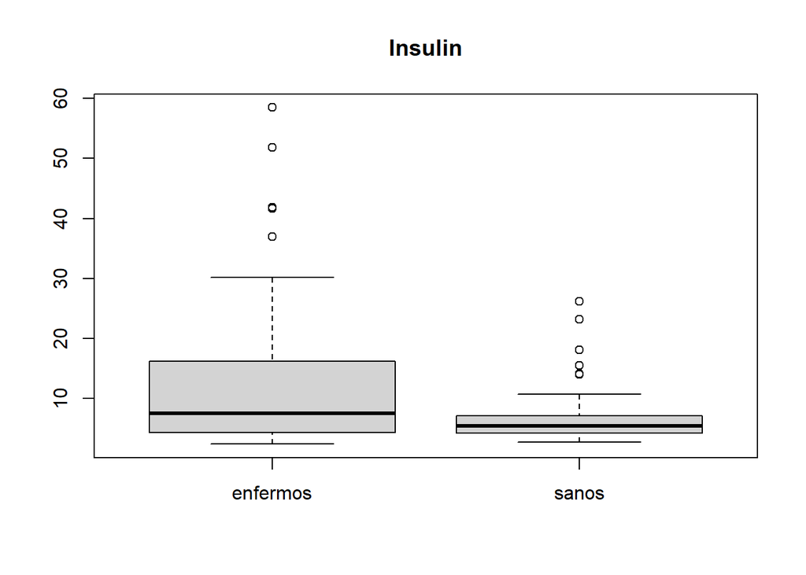

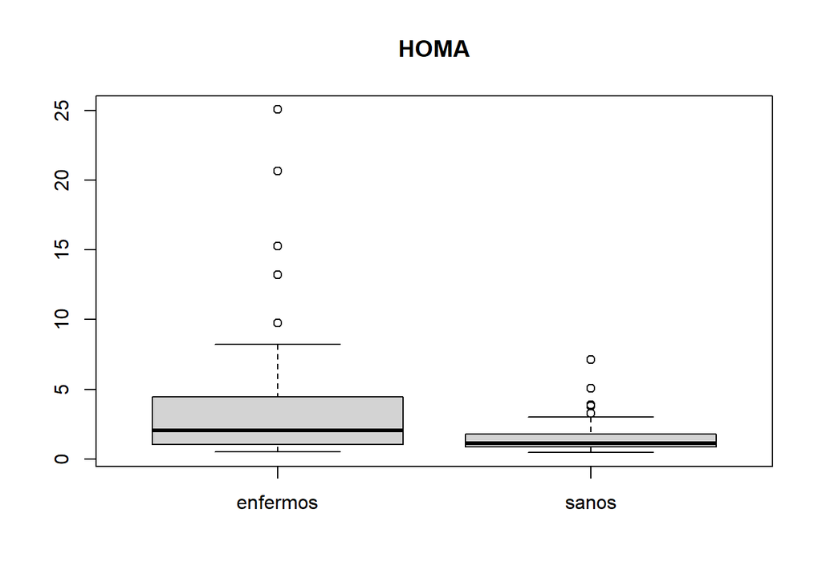

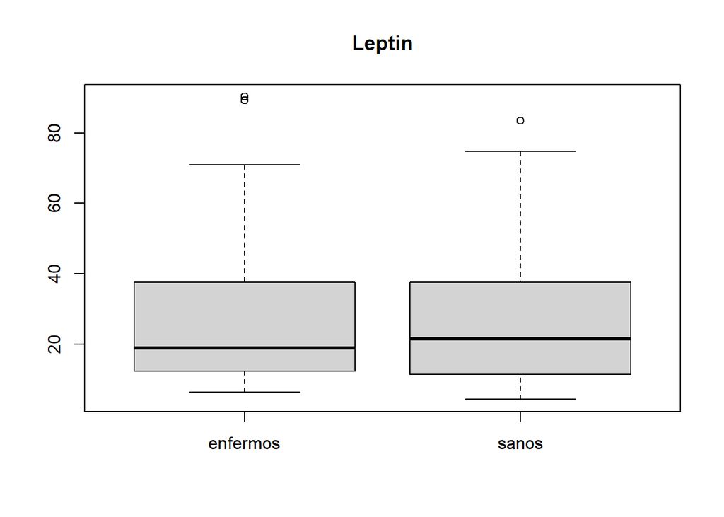

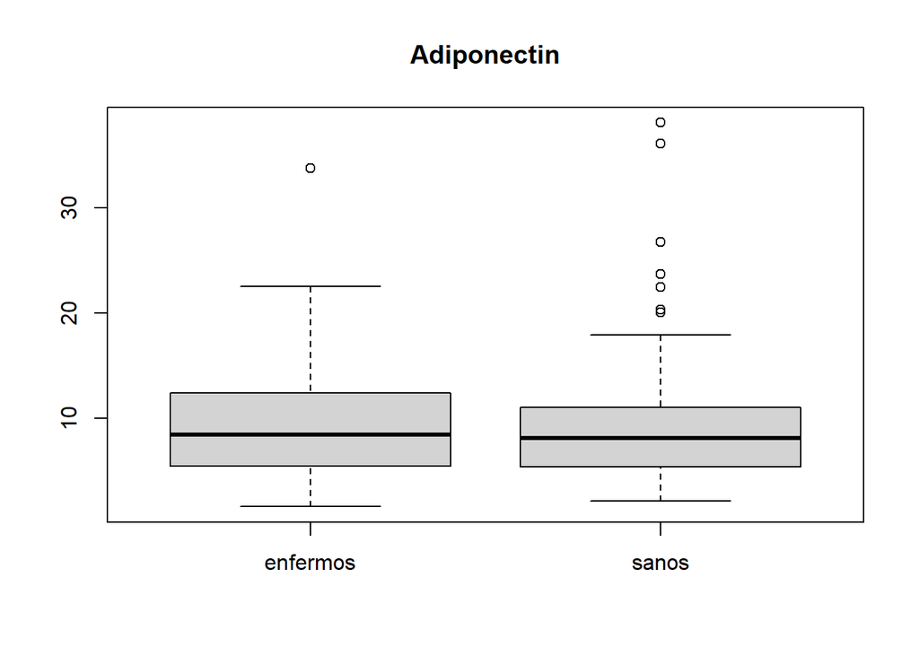

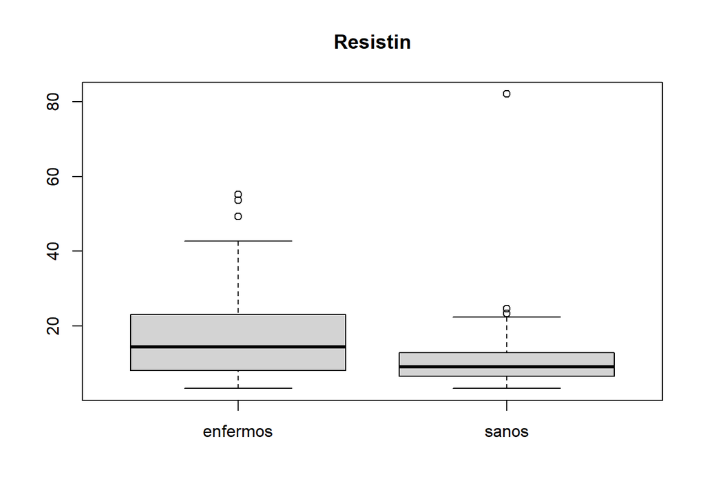

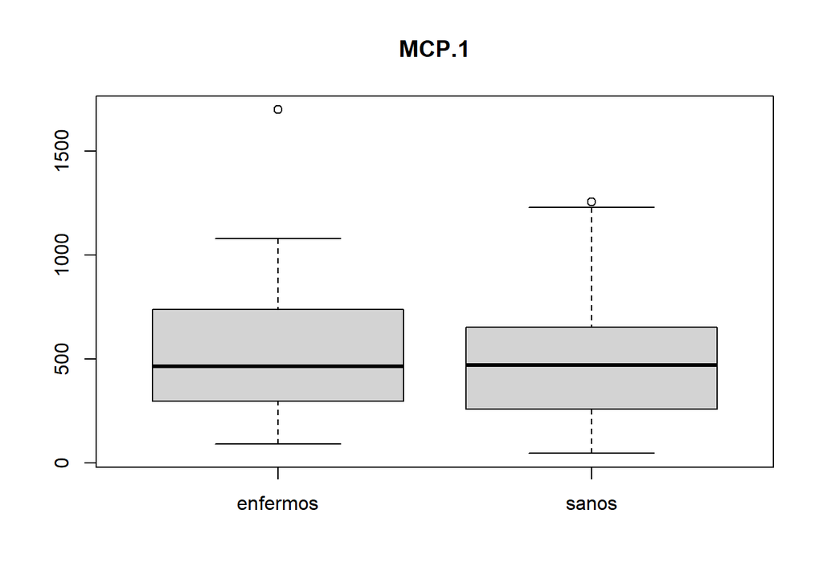

```r
for (val in names(coimbra_data[, 0:9])){
  boxplot(coimbra_data[val][coimbra_data$Classification == 2,],coimbra_data[val][coimbra_data$Classification == 1,], names=c('enfermos','sanos'))
  title(val)
}
```

Usamos el siguiente fragmento de código para generar las gráficas de densidad y dispersion

```r
val=names(coimbra_bar[, 0:9])
coimbra_bar$Classification<-as.factor(coimbra_bar$Classification)
i=9
p<-ggplot(coimbra_bar, aes(x=eval(as.symbol(val[i])), fill=Classification)) +
    geom_density(position="identity", alpha=0.5)+ labs(
                      y="Densidad", x = val[i],fill = "Estado")


png(paste(val[i],'.png',sep=''))
p
dev.off()
```

```r
p<-ggplot(coimbra_bar, aes(x=Classification, y=eval(as.symbol(val[i])), color=Classification)) +
    geom_boxplot()+ labs(
                      y="Distribución", x = val[i],color = "Estado")
png(paste(val[i],'b.png',sep=''))

p
dev.off()
```

Calculamos la correlación entre variables no objetivo

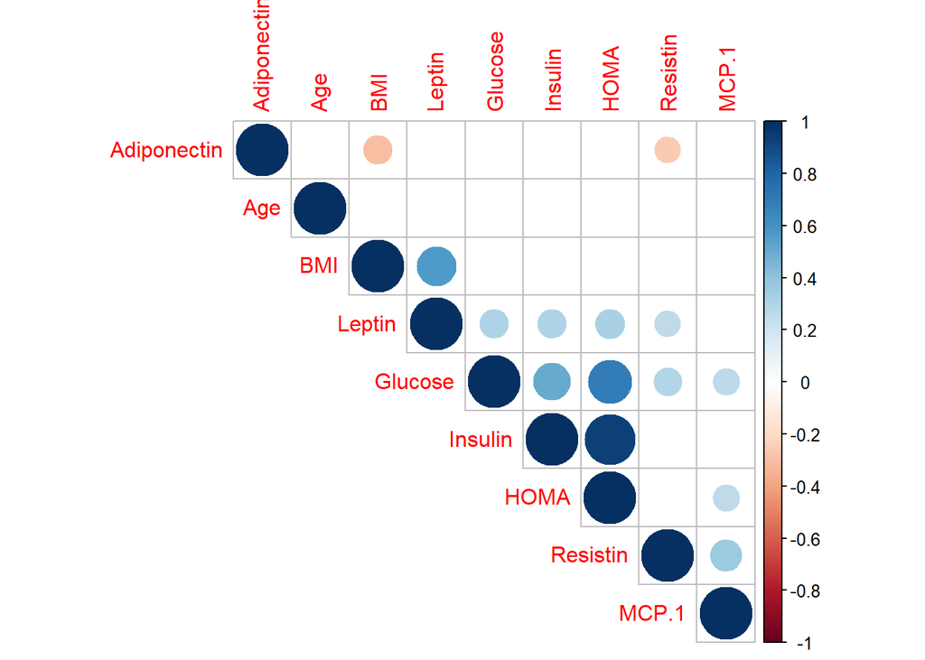

```r
correlacion <- rcorr(as.matrix(coimbra_data[, 0:9]))

corrplot(correlacion$r, type="upper", order="hclust",
         p.mat = correlacion$P, sig.level = 0.01, insig = "blank")
```

Construyo el pairplot apra estudiar ambas variables

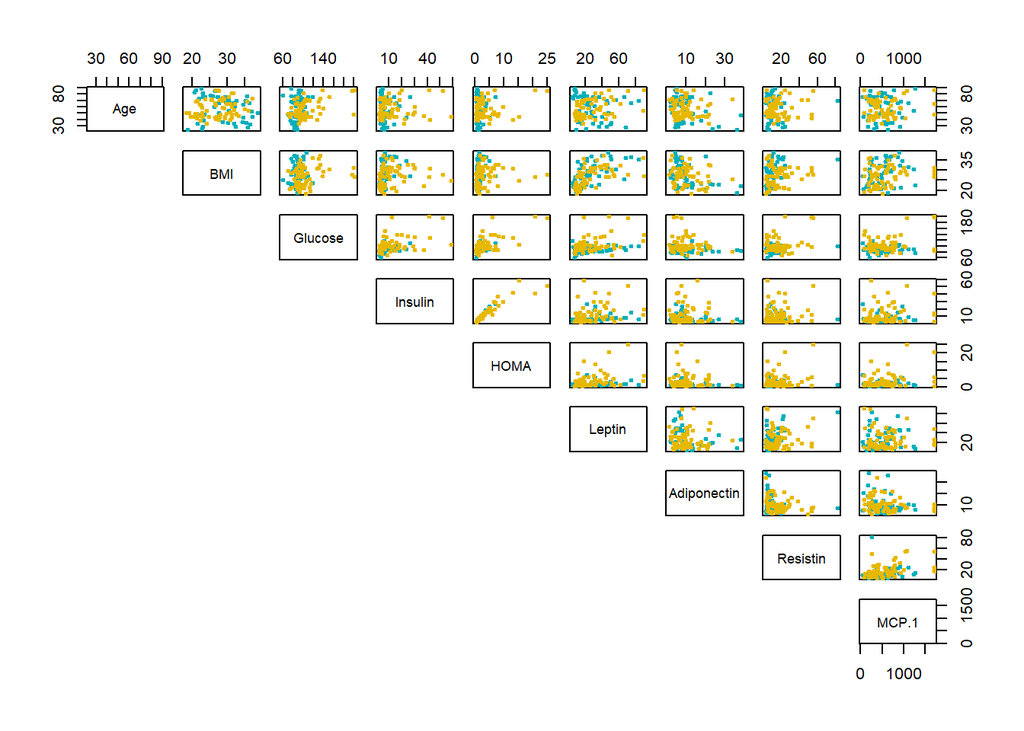

```r
my_cols <- c("#00AFBB", "#E7B800")
pairs(coimbra_data[, 0:9], pch = 19,  cex = 0.5,
      col = my_cols[coimbra_data$Classification],
      lower.panel=NULL)
```

Realizamos el pair plot por categoria y lo enviamos a un pdf por temas de visualización

```r
# Correlation panel
panel.cor <- function(x, y){
    usr <- par("usr"); on.exit(par(usr))
    par(usr = c(0, 1, 0, 1))
    r <- round(cor(x, y), digits=2)
    txt <- paste0("R = ", r)
    cex.cor <- 0.8/strwidth(txt)
    text(0.5, 0.5, txt, cex = cex.cor * r)
}
# Customize upper panel
my_cols <- c("#00AFBB", "#E7B800")
upper.panel<-function(x, y){
  points(x,y, pch = 19,  cex = 0.5, col = my_cols[coimbra_data$Classification])
}
# Create the plots

pdf(file = "yourPlots.pdf")


pairs(coimbra_data[, 0:9],
      lower.panel = panel.cor,
      upper.panel = upper.panel)
dev.off()  # important!
```

Creamos los 3 conjuntos de datos qeu vana ser tomados en consideración

```r
coimbra_data$Classification=unlist(lapply(coimbra_data$Classification, function(x) ifelse(x==1,'sano','enfermo') ))
coimbra_data$Classification=as.factor(coimbra_data$Classification)
coimbra_9_orig<-coimbra_data
coimbra_4_orig<-coimbra_data %>% select('Age', 'BMI', 'Glucose', 'Resistin','Classification')
```

Creamos un conjunto derivado de la aplicación de técnicas de reducción de la dimensionalidad a partir del dataset de 9 original

```r
coimbra.pca <- prcomp(coimbra_9_orig[-10], scale=T)
coimbra.pca
```

```
## Standard deviations (1, .., p=9):
## [1] 1.7488681 1.2337752 1.0805294 1.0515218 0.8500249 0.8107276 0.6644927
## [8] 0.5409473 0.1789447
##
## Rotation (n x k) = (9 x 9):
##                    PC1         PC2         PC3          PC4        PC5
## Age          0.1245739  0.06626166 -0.20670086  0.821387749  0.2529717
## BMI          0.2604297  0.49933879  0.42573480 -0.070921589 -0.2324569
## Glucose      0.4390227 -0.18594179 -0.13088534  0.125615405  0.1995197
## Insulin      0.4439787 -0.38631334  0.09371342 -0.059771821 -0.2976113
## HOMA         0.4928517 -0.37472788 -0.01219108 -0.005644021 -0.1391521
## Leptin       0.3314935  0.23364275  0.58320150  0.058353947  0.2878059
## Adiponectin -0.1726096 -0.48059810  0.28212343 -0.276866882  0.5292842
## Resistin     0.2817413  0.30361887 -0.28892346 -0.302703643  0.5975961
## MCP.1        0.2546307  0.21044940 -0.49675794 -0.359469872 -0.1188700
##                     PC6         PC7         PC8          PC9
## Age         -0.29483811  0.30785182 -0.12712772 -0.028796676
## BMI         -0.27652419 -0.05332906 -0.59945409  0.062178063
## Glucose     -0.03011844 -0.80716167 -0.08449350 -0.201022847
## Insulin      0.12162117  0.39056498 -0.09436728 -0.613579380
## HOMA         0.06763632  0.13142043 -0.01629459  0.758301332
## Leptin      -0.02159401  0.05409473  0.63623826 -0.031145986
## Adiponectin -0.48846279  0.10252955 -0.23175112 -0.004889575
## Resistin     0.42081192  0.24436211 -0.24326258 -0.015424508
## MCP.1       -0.63260295  0.08893578  0.30083068 -0.046497241
```

```r
summary(coimbra.pca)
```

```
## Importance of components:
##                           PC1    PC2    PC3    PC4     PC5     PC6     PC7
## Standard deviation     1.7489 1.2338 1.0805 1.0515 0.85002 0.81073 0.66449
## Proportion of Variance 0.3398 0.1691 0.1297 0.1229 0.08028 0.07303 0.04906
## Cumulative Proportion  0.3398 0.5090 0.6387 0.7615 0.84184 0.91487 0.96393
##                            PC8     PC9
## Standard deviation     0.54095 0.17894
## Proportion of Variance 0.03251 0.00356
## Cumulative Proportion  0.99644 1.00000
```

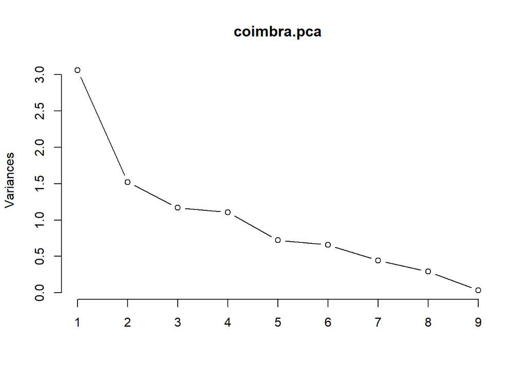

```r
plot(coimbra.pca,type="lines")
```

```r
coimbra_PCA=as.data.frame((coimbra.pca$x))
coimbra_PCA=coimbra_PCA[,0:6]
coimbra_PCA$Classification=coimbra_9_orig$Classification
```

Partimos los datos para el proceso de aprendizaje en los 6 datasets finales

```r
set.seed(998)
inTraining <- createDataPartition(coimbra_9_orig$Classification, p = .70, list = FALSE)
Coimbra_train_9 <- coimbra_9_orig[ inTraining,]
Coimbra_test_9  <- coimbra_9_orig[-inTraining,]

inTraining <- createDataPartition(coimbra_4_orig$Classification, p = .70, list = FALSE)
Coimbra_train_4 <- coimbra_4_orig[ inTraining,]
Coimbra_test_4  <- coimbra_4_orig[-inTraining,]

inTraining <- createDataPartition(coimbra_PCA$Classification, p = .70, list = FALSE)
Coimbra_train_PCA <- coimbra_PCA[ inTraining,]
Coimbra_test_PCA <- coimbra_PCA[-inTraining,]
```

Creamos la línea base con los modelos inciales para árboles de decisión Modelos base

```r
DT_base_9<-C5.0(x = Coimbra_train_9[-10], y = Coimbra_train_9$Classification)
DT_base_9_pred <- predict(DT_base_9, Coimbra_test_9[-10])

confusionMatrix(data = as.factor(DT_base_9_pred), reference = as.factor(Coimbra_test_9$Classification))
```

```
## Confusion Matrix and Statistics
##
##           Reference
## Prediction enfermo sano
##    enfermo      16    5
##    sano          3   10
##
##                Accuracy : 0.7647
##                  95% CI : (0.5883, 0.8925)
##     No Information Rate : 0.5588
##     P-Value [Acc > NIR] : 0.01073
##
##                   Kappa : 0.516
##
##  Mcnemar's Test P-Value : 0.72367
##
##             Sensitivity : 0.8421
##             Specificity : 0.6667
##          Pos Pred Value : 0.7619
##          Neg Pred Value : 0.7692
##              Prevalence : 0.5588
##          Detection Rate : 0.4706
##    Detection Prevalence : 0.6176
##       Balanced Accuracy : 0.7544
##
##        'Positive' Class : enfermo
##
```

```r
DT_base_4<-C5.0(x = Coimbra_train_4[-5], y = Coimbra_train_4$Classification)
DT_base_4_pred <- predict(DT_base_4, Coimbra_test_4[-5])

confusionMatrix(data = as.factor(DT_base_4_pred), reference = as.factor(Coimbra_test_4$Classification))
```

```
## Confusion Matrix and Statistics
##
##           Reference
## Prediction enfermo sano
##    enfermo      15    3
##    sano          4   12
##
##                Accuracy : 0.7941
##                  95% CI : (0.621, 0.913)
##     No Information Rate : 0.5588
##     P-Value [Acc > NIR] : 0.003731
##
##                   Kappa : 0.5854
##
##  Mcnemar's Test P-Value : 1.000000
##
##             Sensitivity : 0.7895
##             Specificity : 0.8000
##          Pos Pred Value : 0.8333
##          Neg Pred Value : 0.7500
##              Prevalence : 0.5588
##          Detection Rate : 0.4412
##    Detection Prevalence : 0.5294
##       Balanced Accuracy : 0.7947
##
##        'Positive' Class : enfermo
##
```

```r
DT_base_PCA<-C5.0(x = Coimbra_train_PCA[-7], y = Coimbra_train_PCA$Classification)
DT_base_PCA_pred <- predict(DT_base_PCA, Coimbra_test_PCA[-7])

confusionMatrix(data = as.factor(DT_base_PCA_pred), reference = as.factor(Coimbra_test_PCA$Classification))
```

```
## Confusion Matrix and Statistics
##
##           Reference
## Prediction enfermo sano
##    enfermo      11    5
##    sano          8   10
##
##                Accuracy : 0.6176
##                  95% CI : (0.4356, 0.7783)
##     No Information Rate : 0.5588
##     P-Value [Acc > NIR] : 0.3043
##
##                   Kappa : 0.2405
##
##  Mcnemar's Test P-Value : 0.5791
##
##             Sensitivity : 0.5789
##             Specificity : 0.6667
##          Pos Pred Value : 0.6875
##          Neg Pred Value : 0.5556
##              Prevalence : 0.5588
##          Detection Rate : 0.3235
##    Detection Prevalence : 0.4706
##       Balanced Accuracy : 0.6228
##
##        'Positive' Class : enfermo
##
```

Modelos Optimos de Árboles de decisión

```r
fitControl <- trainControl(## 10-fold CV
                           method = "repeatedcv", classProbs = TRUE,
                     summaryFunction = twoClassSummary,number=5,repeats=10,search='grid')
grid <- expand.grid( .winnow = c(TRUE,FALSE), .trials=1, .model=c("tree","rules") )
```

```r
DT_Optim_9 <- train(Coimbra_train_9[-10],as.factor(Coimbra_train_9$Classification),
                 method ='C5.0',
                 trControl = fitControl,
                 metric='ROC',
                 tuneGrid=grid,
                 ## This last option is actually one
                 ## for gbm() that passes through
                 verbose = FALSE)


DT_Optim_9_pred <- predict(DT_Optim_9, Coimbra_test_9[-10])


DT_Optim_9
```

```
## C5.0
##
## 82 samples
##  9 predictor
##  2 classes: 'enfermo', 'sano'
##
## No pre-processing
## Resampling: Cross-Validated (5 fold, repeated 10 times)
## Summary of sample sizes: 65, 66, 66, 65, 66, 65, ...
## Resampling results across tuning parameters:
##
##   model  winnow  ROC        Sens       Spec
##   rules  FALSE   0.6434524  0.7177778  0.5300000
##   rules   TRUE   0.6099405  0.6911111  0.5239286
##   tree   FALSE   0.6484524  0.7200000  0.5396429
##   tree    TRUE   0.6175397  0.6888889  0.5210714
##
## Tuning parameter 'trials' was held constant at a value of 1
## ROC was used to select the optimal model using the largest value.
## The final values used for the model were trials = 1, model = tree and winnow
##  = FALSE.
```

```r
confusionMatrix(data = as.factor(DT_Optim_9_pred), reference = as.factor(Coimbra_test_9$Classification))
```

```
## Confusion Matrix and Statistics
##
##           Reference
## Prediction enfermo sano
##    enfermo      16    5
##    sano          3   10
##
##                Accuracy : 0.7647
##                  95% CI : (0.5883, 0.8925)
##     No Information Rate : 0.5588
##     P-Value [Acc > NIR] : 0.01073
##
##                   Kappa : 0.516
##
##  Mcnemar's Test P-Value : 0.72367
##
##             Sensitivity : 0.8421
##             Specificity : 0.6667
##          Pos Pred Value : 0.7619
##          Neg Pred Value : 0.7692
##              Prevalence : 0.5588
##          Detection Rate : 0.4706
##    Detection Prevalence : 0.6176
##       Balanced Accuracy : 0.7544
##
##        'Positive' Class : enfermo
##
```

```r
DT_Optim_4 <- train(Coimbra_train_4[-5],as.factor(Coimbra_train_4$Classification),
                 method ='C5.0',
                 trControl = fitControl,
                 metric='ROC',
                 tuneGrid=grid,
                 ## This last option is actually one
                 ## for gbm() that passes through
                 verbose = FALSE)


DT_Optim_4_pred <- predict(DT_Optim_4, Coimbra_test_4[-5])


DT_Optim_4
```

```
## C5.0
##
## 82 samples
##  4 predictor
##  2 classes: 'enfermo', 'sano'
##
## No pre-processing
## Resampling: Cross-Validated (5 fold, repeated 10 times)
## Summary of sample sizes: 66, 66, 66, 65, 65, 65, ...
## Resampling results across tuning parameters:
##
##   model  winnow  ROC        Sens       Spec
##   rules  FALSE   0.6968651  0.7466667  0.6332143
##   rules   TRUE   0.6423810  0.7000000  0.5789286
##   tree   FALSE   0.7099008  0.7422222  0.6246429
##   tree    TRUE   0.6528968  0.6977778  0.5739286
##
## Tuning parameter 'trials' was held constant at a value of 1
## ROC was used to select the optimal model using the largest value.
## The final values used for the model were trials = 1, model = tree and winnow
##  = FALSE.
```

```r
confusionMatrix(data = as.factor(DT_Optim_4_pred), reference = as.factor(Coimbra_test_4$Classification))
```

```
## Confusion Matrix and Statistics
##
##           Reference
## Prediction enfermo sano
##    enfermo      15    3
##    sano          4   12
##
##                Accuracy : 0.7941
##                  95% CI : (0.621, 0.913)
##     No Information Rate : 0.5588
##     P-Value [Acc > NIR] : 0.003731
##
##                   Kappa : 0.5854
##
##  Mcnemar's Test P-Value : 1.000000
##
##             Sensitivity : 0.7895
##             Specificity : 0.8000
##          Pos Pred Value : 0.8333
##          Neg Pred Value : 0.7500
##              Prevalence : 0.5588
##          Detection Rate : 0.4412
##    Detection Prevalence : 0.5294
##       Balanced Accuracy : 0.7947
##
##        'Positive' Class : enfermo
##
```

```r
DT_Optim_PCA <- train(Coimbra_train_PCA[-7],as.factor(Coimbra_train_PCA$Classification),
                 method ='C5.0',
                 trControl = fitControl,
                 metric='ROC',
                 tuneGrid=grid,
                 ## This last option is actually one
                 ## for gbm() that passes through
                 verbose = FALSE)


DT_Optim_PCA_pred <- predict(DT_Optim_PCA, Coimbra_test_PCA[-7])


DT_Optim_PCA
```

```
## C5.0
##
## 82 samples
##  6 predictor
##  2 classes: 'enfermo', 'sano'
##
## No pre-processing
## Resampling: Cross-Validated (5 fold, repeated 10 times)
## Summary of sample sizes: 65, 66, 66, 65, 66, 65, ...
## Resampling results across tuning parameters:
##
##   model  winnow  ROC        Sens       Spec
##   rules  FALSE   0.6349405  0.7133333  0.5500000
##   rules   TRUE   0.5900595  0.7000000  0.4782143
##   tree   FALSE   0.6537698  0.7111111  0.5439286
##   tree    TRUE   0.6041667  0.7000000  0.4782143
##
## Tuning parameter 'trials' was held constant at a value of 1
## ROC was used to select the optimal model using the largest value.
## The final values used for the model were trials = 1, model = tree and winnow
##  = FALSE.
```

```r
confusionMatrix(data = as.factor(DT_Optim_PCA_pred), reference = as.factor(Coimbra_test_PCA$Classification))
```

```
## Confusion Matrix and Statistics
##
##           Reference
## Prediction enfermo sano
##    enfermo      11    5
##    sano          8   10
##
##                Accuracy : 0.6176
##                  95% CI : (0.4356, 0.7783)
##     No Information Rate : 0.5588
##     P-Value [Acc > NIR] : 0.3043
##
##                   Kappa : 0.2405
##
##  Mcnemar's Test P-Value : 0.5791
##
##             Sensitivity : 0.5789
##             Specificity : 0.6667
##          Pos Pred Value : 0.6875
##          Neg Pred Value : 0.5556
##              Prevalence : 0.5588
##          Detection Rate : 0.3235
##    Detection Prevalence : 0.4706
##       Balanced Accuracy : 0.6228
##
##        'Positive' Class : enfermo
##
```

Modelo base para random forest

```r
set.seed(400)
RF_base_9<-randomForest(x = Coimbra_train_9[-10], y = Coimbra_train_9$Classification)


RF_base_9_pred <- predict(RF_base_9, Coimbra_test_9[-10])

confusionMatrix(data = as.factor(RF_base_9_pred), reference = as.factor(Coimbra_test_9$Classification))
```

```
## Confusion Matrix and Statistics
##
##           Reference
## Prediction enfermo sano
##    enfermo      16    3
##    sano          3   12
##
##                Accuracy : 0.8235
##                  95% CI : (0.6547, 0.9324)
##     No Information Rate : 0.5588
##     P-Value [Acc > NIR] : 0.001104
##
##                   Kappa : 0.6421
##
##  Mcnemar's Test P-Value : 1.000000
##
##             Sensitivity : 0.8421
##             Specificity : 0.8000
##          Pos Pred Value : 0.8421
##          Neg Pred Value : 0.8000
##              Prevalence : 0.5588
##          Detection Rate : 0.4706
##    Detection Prevalence : 0.5588
##       Balanced Accuracy : 0.8211
##
##        'Positive' Class : enfermo
##
```

```r
set.seed(400)
RF_base_4<-randomForest(x = Coimbra_train_4[-5], y = Coimbra_train_4$Classification)


RF_base_4_pred <- predict(RF_base_4, Coimbra_test_4[-5])

confusionMatrix(data = as.factor(RF_base_4_pred), reference = as.factor(Coimbra_test_4$Classification))
```

```
## Confusion Matrix and Statistics
##
##           Reference
## Prediction enfermo sano
##    enfermo      13    4
##    sano          6   11
##
##                Accuracy : 0.7059
##                  95% CI : (0.5252, 0.849)
##     No Information Rate : 0.5588
##     P-Value [Acc > NIR] : 0.0582
##
##                   Kappa : 0.4118
##
##  Mcnemar's Test P-Value : 0.7518
##
##             Sensitivity : 0.6842
##             Specificity : 0.7333
##          Pos Pred Value : 0.7647
##          Neg Pred Value : 0.6471
##              Prevalence : 0.5588
##          Detection Rate : 0.3824
##    Detection Prevalence : 0.5000
##       Balanced Accuracy : 0.7088
##
##        'Positive' Class : enfermo
##
```

```r
set.seed(400)
RF_base_PCA<-randomForest(x = Coimbra_train_PCA[-7], y = Coimbra_train_PCA$Classification)


RF_base_PCA_pred <- predict(RF_base_PCA, Coimbra_test_PCA[-7])

confusionMatrix(data = as.factor(RF_base_PCA_pred), reference = as.factor(Coimbra_test_PCA$Classification))
```

```
## Confusion Matrix and Statistics
##
##           Reference
## Prediction enfermo sano
##    enfermo      12    4
##    sano          7   11
##
##                Accuracy : 0.6765
##                  95% CI : (0.4947, 0.8261)
##     No Information Rate : 0.5588
##     P-Value [Acc > NIR] : 0.1125
##
##                   Kappa : 0.3574
##
##  Mcnemar's Test P-Value : 0.5465
##
##             Sensitivity : 0.6316
##             Specificity : 0.7333
##          Pos Pred Value : 0.7500
##          Neg Pred Value : 0.6111
##              Prevalence : 0.5588
##          Detection Rate : 0.3529
##    Detection Prevalence : 0.4706
##       Balanced Accuracy : 0.6825
##
##        'Positive' Class : enfermo
##
```

Modelos Optimos de Random Forest

```r
fitControl <- trainControl(## 10-fold CV
                           method = "repeatedcv", classProbs = TRUE,
                     summaryFunction = twoClassSummary,number=5,repeats=10,search='grid')
grid <- expand.grid( .mtry = c(1,2,3,4
                               ,5,6,7,8,9))
```

```r
set.seed(400)
modellist <- list()
for (ntree in c(500,1000,1500,2000,2500)){
  RF_Optim_9 <- train(Coimbra_train_9[-10],as.factor(Coimbra_train_9$Classification),
                   method ='rf',
                   trControl = fitControl,
                   metric='ROC',
                   tuneGrid=grid,
                   ntree=ntree,
                   ## This last option is actually one
                   ## for gbm() that passes through
                   verbose = FALSE)
  key <- toString(ntree)
  modellist[[key]] <- RF_Optim_9
}
results <- resamples(modellist)
summary(results)
```

```
##
## Call:
## summary.resamples(object = results)
##
## Models: 500, 1000, 1500, 2000, 2500
## Number of resamples: 50
##
## ROC
##           Min.   1st Qu.    Median      Mean   3rd Qu.      Max. NA's
## 500  0.6031746 0.7242063 0.8095238 0.7944246 0.8601190 0.9523810    0
## 1000 0.4603175 0.7142857 0.7847222 0.7800595 0.8457341 0.9722222    0
## 1500 0.3492063 0.7137897 0.8055556 0.7856548 0.8601190 1.0000000    0
## 2000 0.5873016 0.7301587 0.7916667 0.7852579 0.8412698 1.0000000    0
## 2500 0.5714286 0.7083333 0.7926587 0.7792857 0.8571429 0.9682540    0
##
## Sens
##           Min.   1st Qu.    Median      Mean   3rd Qu. Max. NA's
## 500  0.4444444 0.6666667 0.7777778 0.7488889 0.8888889    1    0
## 1000 0.3333333 0.6666667 0.7777778 0.7822222 0.8888889    1    0
## 1500 0.4444444 0.6666667 0.7777778 0.7822222 0.8888889    1    0
## 2000 0.4444444 0.6944444 0.7777778 0.7822222 0.8888889    1    0
## 2500 0.4444444 0.6666667 0.7777778 0.7355556 0.8888889    1    0
##
## Spec
##           Min.   1st Qu. Median      Mean   3rd Qu.  Max. NA's
## 500  0.2857143 0.5178571  0.625 0.6400000 0.7500000 1.000    0
## 1000 0.1250000 0.5000000  0.625 0.6200000 0.7500000 1.000    0
## 1500 0.1428571 0.5000000  0.625 0.6117857 0.7142857 1.000    0
## 2000 0.1428571 0.5000000  0.625 0.6182143 0.7500000 0.875    0
## 2500 0.3750000 0.5714286  0.625 0.6403571 0.7410714 0.875    0
```

```r
set.seed(400)
#Me quedo con el valor de ntree que mejores resultados haya obtenido antes
RF_Optim_9 <- train(Coimbra_train_9[-10],as.factor(Coimbra_train_9$Classification),
                   method ='rf',
                   trControl = fitControl,
                   metric='ROC',
                   tuneGrid=grid,
                   ntree=500,
                   ## This last option is actually one
                   ## for gbm() that passes through
                   verbose = FALSE)
RF_Optim_9_pred <- predict(RF_Optim_9, Coimbra_test_9[-10])

RF_Optim_9
```

```
## Random Forest
##
## 82 samples
##  9 predictor
##  2 classes: 'enfermo', 'sano'
##
## No pre-processing
## Resampling: Cross-Validated (5 fold, repeated 10 times)
## Summary of sample sizes: 66, 66, 65, 65, 66, 65, ...
## Resampling results across tuning parameters:
##
##   mtry  ROC        Sens       Spec
##   1     0.7926786  0.7755556  0.6314286
##   2     0.7889286  0.7644444  0.6471429
##   3     0.7944048  0.7555556  0.6460714
##   4     0.7944246  0.7488889  0.6400000
##   5     0.7893849  0.7400000  0.6407143
##   6     0.7808929  0.7355556  0.6482143
##   7     0.7854563  0.7422222  0.6489286
##   8     0.7822421  0.7333333  0.6428571
##   9     0.7779563  0.7266667  0.6400000
##
## ROC was used to select the optimal model using the largest value.
## The final value used for the model was mtry = 4.
```

```r
confusionMatrix(data = as.factor(RF_Optim_9_pred), reference = as.factor(Coimbra_test_9$Classification))
```

```
## Confusion Matrix and Statistics
##
##           Reference
## Prediction enfermo sano
##    enfermo      16    2
##    sano          3   13
##
##                Accuracy : 0.8529
##                  95% CI : (0.6894, 0.9505)
##     No Information Rate : 0.5588
##     P-Value [Acc > NIR] : 0.0002725
##
##                   Kappa : 0.7038
##
##  Mcnemar's Test P-Value : 1.0000000
##
##             Sensitivity : 0.8421
##             Specificity : 0.8667
##          Pos Pred Value : 0.8889
##          Neg Pred Value : 0.8125
##              Prevalence : 0.5588
##          Detection Rate : 0.4706
##    Detection Prevalence : 0.5294
##       Balanced Accuracy : 0.8544
##
##        'Positive' Class : enfermo
##
```

```r
fitControl <- trainControl(## 10-fold CV
                           method = "repeatedcv", classProbs = TRUE,
                     summaryFunction = twoClassSummary,number=5,repeats=10,search='grid')
grid <- expand.grid( .mtry = c(1,2,3,4))
```

```r
set.seed(400)
modellist <- list()
#Me quedo con el valor de ntree que mejores resultados haya obtenido antes
for (ntree in c(500,1000,1500,2000,2500)){
  RF_Optim_4 <- train(Coimbra_train_4[-5],as.factor(Coimbra_train_4$Classification),
                   method ='rf',
                   trControl = fitControl,
                   metric='ROC',
                   tuneGrid=grid,
                   ntree=ntree,
                   ## This last option is actually one
                   ## for gbm() that passes through
                   verbose = FALSE)
  key <- toString(ntree)
  modellist[[key]] <- RF_Optim_4
}
results <- resamples(modellist)
summary(results)
```

```
##
## Call:
## summary.resamples(object = results)
##
## Models: 500, 1000, 1500, 2000, 2500
## Number of resamples: 50
##
## ROC
##           Min.   1st Qu.    Median      Mean   3rd Qu. Max. NA's
## 500  0.7063492 0.8035714 0.8680556 0.8628175 0.9206349    1    0
## 1000 0.6507937 0.7921627 0.8521825 0.8552579 0.9136905    1    0
## 1500 0.5714286 0.8253968 0.8730159 0.8646032 0.9196429    1    0
## 2000 0.6507937 0.8055556 0.8730159 0.8584921 0.9047619    1    0
## 2500 0.5714286 0.8065476 0.8670635 0.8590873 0.9206349    1    0
##
## Sens
##           Min.   1st Qu.    Median      Mean   3rd Qu. Max. NA's
## 500  0.5555556 0.7777778 0.7777778 0.8044444 0.8888889    1    0
## 1000 0.4444444 0.6666667 0.7777778 0.8022222 0.8888889    1    0
## 1500 0.3333333 0.6666667 0.7777778 0.7911111 0.8888889    1    0
## 2000 0.4444444 0.6944444 0.7777778 0.8044444 0.8888889    1    0
## 2500 0.3333333 0.6666667 0.8333333 0.8044444 0.8888889    1    0
##
## Spec
##           Min.   1st Qu.    Median      Mean   3rd Qu. Max. NA's
## 500  0.4285714 0.5714286 0.7500000 0.7389286 0.8571429    1    0
## 1000 0.4285714 0.6250000 0.7500000 0.7567857 0.8705357    1    0
## 1500 0.4285714 0.6250000 0.7500000 0.7550000 0.8750000    1    0
## 2000 0.4285714 0.7142857 0.7500000 0.7578571 0.8571429    1    0
## 2500 0.2857143 0.6250000 0.8571429 0.7600000 0.8750000    1    0
```

```r
set.seed(400)
RF_Optim_4 <- train(Coimbra_train_4[-5],as.factor(Coimbra_train_4$Classification),
                   method ='rf',
                   trControl = fitControl,
                   metric='ROC',
                   tuneGrid=grid,
                   ntree=1500,
                   ## This last option is actually one
                   ## for gbm() that passes through
                   verbose = FALSE)
RF_Optim_4_pred <- predict(RF_Optim_4, Coimbra_test_4[-5])

RF_Optim_4
```

```
## Random Forest
##
## 82 samples
##  4 predictor
##  2 classes: 'enfermo', 'sano'
##
## No pre-processing
## Resampling: Cross-Validated (5 fold, repeated 10 times)
## Summary of sample sizes: 66, 66, 65, 65, 66, 65, ...
## Resampling results across tuning parameters:
##
##   mtry  ROC        Sens       Spec
##   1     0.8620437  0.8000000  0.7435714
##   2     0.8540079  0.7777778  0.7567857
##   3     0.8441270  0.7688889  0.7485714
##   4     0.8370238  0.7444444  0.7403571
##
## ROC was used to select the optimal model using the largest value.
## The final value used for the model was mtry = 1.
```

```r
confusionMatrix(data = as.factor(RF_Optim_4_pred), reference = as.factor(Coimbra_test_4$Classification))
```

```
## Confusion Matrix and Statistics
##
##           Reference
## Prediction enfermo sano
##    enfermo      15    5
##    sano          4   10
##
##                Accuracy : 0.7353
##                  95% CI : (0.5564, 0.8712)
##     No Information Rate : 0.5588
##     P-Value [Acc > NIR] : 0.02669
##
##                   Kappa : 0.4594
##
##  Mcnemar's Test P-Value : 1.00000
##
##             Sensitivity : 0.7895
##             Specificity : 0.6667
##          Pos Pred Value : 0.7500
##          Neg Pred Value : 0.7143
##              Prevalence : 0.5588
##          Detection Rate : 0.4412
##    Detection Prevalence : 0.5882
##       Balanced Accuracy : 0.7281
##
##        'Positive' Class : enfermo
##
```

```r
fitControl <- trainControl(## 10-fold CV
                           method = "repeatedcv", classProbs = TRUE,
                     summaryFunction = twoClassSummary,number=5,repeats=10,search='grid')
grid <- expand.grid( .mtry = c(1,2,3,4
                               ,5,6))
```

```r
set.seed(400)
modellist <- list()
for (ntree in c(500,1000,1500,2000,2500)){
  RF_Optim_PCA <- train(Coimbra_train_PCA[-7],as.factor(Coimbra_train_PCA$Classification),
                   method ='rf',
                   trControl = fitControl,
                   metric='ROC',
                   tuneGrid=grid,
                   ntree=ntree,
                   ## This last option is actually one
                   ## for gbm() that passes through
                   verbose = FALSE)
  key <- toString(ntree)
  modellist[[key]] <- RF_Optim_PCA
}
results <- resamples(modellist)
summary(results)
```

```
##
## Call:
## summary.resamples(object = results)
##
## Models: 500, 1000, 1500, 2000, 2500
## Number of resamples: 50
##
## ROC
##           Min.   1st Qu.    Median      Mean   3rd Qu.     Max. NA's
## 500  0.5555556 0.7500000 0.8055556 0.8050198 0.8690476 1.000000    0
## 1000 0.3968254 0.7361111 0.8075397 0.7874405 0.8888889 0.968254    0
## 1500 0.5138889 0.7500000 0.8055556 0.8031746 0.8700397 1.000000    0
## 2000 0.5555556 0.7385913 0.8224206 0.8055952 0.9027778 1.000000    0
## 2500 0.5238095 0.7460317 0.7916667 0.7989683 0.8601190 0.984127    0
##
## Sens
##           Min.   1st Qu.    Median      Mean   3rd Qu. Max. NA's
## 500  0.3333333 0.6666667 0.7777778 0.7600000 0.8888889    1    0
## 1000 0.3333333 0.6666667 0.7777778 0.7266667 0.8888889    1    0
## 1500 0.5555556 0.6666667 0.7777778 0.8022222 0.8888889    1    0
## 2000 0.3333333 0.6666667 0.7777778 0.7422222 0.8611111    1    0
## 2500 0.4444444 0.6666667 0.7777778 0.7933333 0.8888889    1    0
##
## Spec
##           Min.   1st Qu.    Median      Mean   3rd Qu. Max. NA's
## 500  0.2857143 0.5714286 0.6696429 0.6771429 0.8571429    1    0
## 1000 0.2500000 0.5000000 0.6696429 0.6603571 0.8571429    1    0
## 1500 0.0000000 0.5714286 0.7142857 0.6614286 0.7500000    1    0
## 2000 0.1250000 0.5714286 0.7142857 0.6850000 0.8571429    1    0
## 2500 0.1428571 0.5714286 0.7142857 0.6575000 0.8303571    1    0
```

```r
set.seed(400)
#Me quedo con el valor de ntree que mejores resultados haya obtenido antes
RF_Optim_PCA <- train(Coimbra_train_PCA[-7],as.factor(Coimbra_train_PCA$Classification),
                   method ='rf',
                   trControl = fitControl,
                   metric='ROC',
                   tuneGrid=grid,
                   ntree=2000,
                   ## This last option is actually one
                   ## for gbm() that passes through
                   verbose = FALSE)
RF_Optim_PCA_pred <- predict(RF_Optim_PCA, Coimbra_test_PCA[-7])

RF_Optim_PCA
```

```
## Random Forest
##
## 82 samples
##  6 predictor
##  2 classes: 'enfermo', 'sano'
##
## No pre-processing
## Resampling: Cross-Validated (5 fold, repeated 10 times)
## Summary of sample sizes: 66, 66, 65, 65, 66, 65, ...
## Resampling results across tuning parameters:
##
##   mtry  ROC        Sens       Spec
##   1     0.8017063  0.8088889  0.6585714
##   2     0.8014881  0.7733333  0.6750000
##   3     0.8050397  0.7644444  0.6807143
##   4     0.8029365  0.7577778  0.6775000
##   5     0.8018452  0.7555556  0.6560714
##   6     0.8068452  0.7555556  0.6671429
##
## ROC was used to select the optimal model using the largest value.
## The final value used for the model was mtry = 6.
```

```r
confusionMatrix(data = as.factor(RF_Optim_PCA_pred), reference = as.factor(Coimbra_test_PCA$Classification))
```

```
## Confusion Matrix and Statistics
##
##           Reference
## Prediction enfermo sano
##    enfermo      12    4
##    sano          7   11
##
##                Accuracy : 0.6765
##                  95% CI : (0.4947, 0.8261)
##     No Information Rate : 0.5588
##     P-Value [Acc > NIR] : 0.1125
##
##                   Kappa : 0.3574
##
##  Mcnemar's Test P-Value : 0.5465
##
##             Sensitivity : 0.6316
##             Specificity : 0.7333
##          Pos Pred Value : 0.7500
##          Neg Pred Value : 0.6111
##              Prevalence : 0.5588
##          Detection Rate : 0.3529
##    Detection Prevalence : 0.4706
##       Balanced Accuracy : 0.6825
##
##        'Positive' Class : enfermo
##
```

Modelo base para GBM

```r
fitControl <- trainControl(## 10-fold CV
                           method = "none", classProbs = TRUE,
                     summaryFunction = twoClassSummary,search='grid')
gbmGrid <-  expand.grid(interaction.depth = c(1),
                        n.trees = 100,
                        shrinkage = 0.1,
                        n.minobsinnode = 10)
```

```r
set.seed(400)
GBM_base_9 <- train(Coimbra_train_9[-10], Coimbra_train_9$Classification,
                 method = "gbm",
                 trControl = fitControl,
                 tuneGrid = gbmGrid,
                 metric='ROC',
                 ## This last option is actually one
                 ## for gbm() that passes through
                 verbose = FALSE)
GBM_base_9
```

```
## Stochastic Gradient Boosting
##
## 82 samples
##  9 predictor
##  2 classes: 'enfermo', 'sano'
##
## No pre-processing
## Resampling: None
```

```r
GBM_base_9_pred <- predict(GBM_base_9, Coimbra_test_9[-10])

confusionMatrix(data = as.factor(GBM_base_9_pred), reference = as.factor(Coimbra_test_9$Classification))
```

```
## Confusion Matrix and Statistics
##
##           Reference
## Prediction enfermo sano
##    enfermo      17    5
##    sano          2   10
##
##                Accuracy : 0.7941
##                  95% CI : (0.621, 0.913)
##     No Information Rate : 0.5588
##     P-Value [Acc > NIR] : 0.003731
##
##                   Kappa : 0.5735
##
##  Mcnemar's Test P-Value : 0.449692
##
##             Sensitivity : 0.8947
##             Specificity : 0.6667
##          Pos Pred Value : 0.7727
##          Neg Pred Value : 0.8333
##              Prevalence : 0.5588
##          Detection Rate : 0.5000
##    Detection Prevalence : 0.6471
##       Balanced Accuracy : 0.7807
##
##        'Positive' Class : enfermo
##
```

```r
set.seed(400)
GBM_base_4 <- train(Coimbra_train_4[-5], Coimbra_train_4$Classification,
                 method = "gbm",
                 trControl = fitControl,
                 tuneGrid = gbmGrid,
                 ## This last option is actually one
                 ## for gbm() that passes through
                 verbose = FALSE)
GBM_base_4
```

```
## Stochastic Gradient Boosting
##
## 82 samples
##  4 predictor
##  2 classes: 'enfermo', 'sano'
##
## No pre-processing
## Resampling: None
```

```r
GBM_base_4_pred <- predict(GBM_base_4, Coimbra_test_4[-5])

confusionMatrix(data = as.factor(GBM_base_4_pred), reference = as.factor(Coimbra_test_4$Classification))
```

```
## Confusion Matrix and Statistics
##
##           Reference
## Prediction enfermo sano
##    enfermo      10    2
##    sano          9   13
##
##                Accuracy : 0.6765
##                  95% CI : (0.4947, 0.8261)
##     No Information Rate : 0.5588
##     P-Value [Acc > NIR] : 0.11247
##
##                   Kappa : 0.3746
##
##  Mcnemar's Test P-Value : 0.07044
##
##             Sensitivity : 0.5263
##             Specificity : 0.8667
##          Pos Pred Value : 0.8333
##          Neg Pred Value : 0.5909
##              Prevalence : 0.5588
##          Detection Rate : 0.2941
##    Detection Prevalence : 0.3529
##       Balanced Accuracy : 0.6965
##
##        'Positive' Class : enfermo
##
```

```r
set.seed(400)
GBM_base_PCA <- train(Coimbra_train_PCA[-7], Coimbra_train_PCA$Classification,
                 method = "gbm",
                 trControl = fitControl,
                 tuneGrid = gbmGrid,
                 ## This last option is actually one
                 ## for gbm() that passes through
                 verbose = FALSE)
GBM_base_PCA
```

```
## Stochastic Gradient Boosting
##
## 82 samples
##  6 predictor
##  2 classes: 'enfermo', 'sano'
##
## No pre-processing
## Resampling: None
```

```r
GBM_base_PCA_pred <- predict(GBM_base_PCA, Coimbra_test_PCA[-7])

confusionMatrix(data = as.factor(GBM_base_PCA_pred), reference = as.factor(Coimbra_test_PCA$Classification))
```

```
## Confusion Matrix and Statistics
##
##           Reference
## Prediction enfermo sano
##    enfermo      13    2
##    sano          6   13
##
##                Accuracy : 0.7647
##                  95% CI : (0.5883, 0.8925)
##     No Information Rate : 0.5588
##     P-Value [Acc > NIR] : 0.01073
##
##                   Kappa : 0.5358
##
##  Mcnemar's Test P-Value : 0.28884
##
##             Sensitivity : 0.6842
##             Specificity : 0.8667
##          Pos Pred Value : 0.8667
##          Neg Pred Value : 0.6842
##              Prevalence : 0.5588
##          Detection Rate : 0.3824
##    Detection Prevalence : 0.4412
##       Balanced Accuracy : 0.7754
##
##        'Positive' Class : enfermo
##
```

Modelos Optimos de GBM

```r
fitControl <- trainControl(## 10-fold CV
                           method = "repeatedcv", classProbs = TRUE,
                     summaryFunction = twoClassSummary,number=5, repeats=10,search='grid')
gbmGrid <-  expand.grid(interaction.depth = c(1, 5, 9),
                        n.trees = c(100,200,300,400,500),
                        shrinkage = c(0.1,0.3,0.5,0.7,0.9),
                        n.minobsinnode = c(3,6,10))
```

```r
set.seed(400)
GBM_optim_9 <- train(Coimbra_train_9[-10], Coimbra_train_9$Classification,
                 method = "gbm",
                 trControl = fitControl,
                 tuneGrid = gbmGrid,
                 metric='ROC',
                 ## This last option is actually one
                 ## for gbm() that passes through
                 verbose = FALSE)
GBM_optim_9
```

```
## Stochastic Gradient Boosting
##
## 82 samples
##  9 predictor
##  2 classes: 'enfermo', 'sano'
##
## No pre-processing
## Resampling: Cross-Validated (5 fold, repeated 10 times)
## Summary of sample sizes: 66, 66, 65, 65, 66, 65, ...
## Resampling results across tuning parameters:
##
##   shrinkage  interaction.depth  n.minobsinnode  n.trees  ROC        Sens
##   0.1        1                   3              100      0.7886905  0.7533333
##   0.1        1                   3              200      0.7719841  0.7622222
##   0.1        1                   3              300      0.7569444  0.7422222
##   0.1        1                   3              400      0.7496825  0.7444444
##   0.1        1                   3              500      0.7478175  0.7377778
##   0.1        1                   6              100      0.7755556  0.7822222
##   0.1        1                   6              200      0.7605159  0.7666667
##   0.1        1                   6              300      0.7534127  0.7511111
##   0.1        1                   6              400      0.7508333  0.7600000
##   0.1        1                   6              500      0.7521032  0.7622222
##   0.1        1                  10              100      0.7794841  0.7911111
##   0.1        1                  10              200      0.7666270  0.7733333
##   0.1        1                  10              300      0.7602778  0.7644444
##   0.1        1                  10              400      0.7601190  0.7577778
##   0.1        1                  10              500      0.7626587  0.7600000
##   0.1        5                   3              100      0.7957143  0.7733333
##   0.1        5                   3              200      0.7863492  0.7666667
##   0.1        5                   3              300      0.7825000  0.7600000
##   0.1        5                   3              400      0.7875794  0.7533333
##   0.1        5                   3              500      0.7830556  0.7511111
##   0.1        5                   6              100      0.7815476  0.7733333
##   0.1        5                   6              200      0.7813095  0.7577778
##   0.1        5                   6              300      0.7809921  0.7555556
##   0.1        5                   6              400      0.7790079  0.7533333
##   0.1        5                   6              500      0.7798016  0.7533333
##   0.1        5                  10              100      0.7888889  0.7800000
##   0.1        5                  10              200      0.7763095  0.7533333
##   0.1        5                  10              300      0.7711111  0.7622222
```

[output cut: 412 more lines]

```
##   0.6096429
##   0.6492857
##   0.6325000
##   0.6407143
##   0.6535714
##   0.6614286
##   0.5717857
##   0.5946429
##   0.6053571
##   0.5975000
##   0.5978571
##
## ROC was used to select the optimal model using the largest value.
## The final values used for the model were n.trees = 100, interaction.depth =
##  5, shrinkage = 0.1 and n.minobsinnode = 3.
```

```r
GBM_optim_9_pred <- predict(GBM_optim_9, Coimbra_test_9[-10])

confusionMatrix(data = as.factor(GBM_optim_9_pred), reference = as.factor(Coimbra_test_9$Classification))
```

```
## Confusion Matrix and Statistics
##
##           Reference
## Prediction enfermo sano
##    enfermo      16    3
##    sano          3   12
##
##                Accuracy : 0.8235
##                  95% CI : (0.6547, 0.9324)
##     No Information Rate : 0.5588
##     P-Value [Acc > NIR] : 0.001104
##
##                   Kappa : 0.6421
##
##  Mcnemar's Test P-Value : 1.000000
##
##             Sensitivity : 0.8421
##             Specificity : 0.8000
##          Pos Pred Value : 0.8421
##          Neg Pred Value : 0.8000
##              Prevalence : 0.5588
##          Detection Rate : 0.4706
##    Detection Prevalence : 0.5588
##       Balanced Accuracy : 0.8211
##
##        'Positive' Class : enfermo
##
```

```r
set.seed(400)
GBM_optim_4 <- train(Coimbra_train_4[-5], Coimbra_train_4$Classification,
                 method = "gbm",
                 trControl = fitControl,
                 tuneGrid = gbmGrid,
                 metric='ROC',
                 ## This last option is actually one
                 ## for gbm() that passes through
                 verbose = FALSE)
GBM_optim_4
```

```
## Stochastic Gradient Boosting
##
## 82 samples
##  4 predictor
##  2 classes: 'enfermo', 'sano'
##
## No pre-processing
## Resampling: Cross-Validated (5 fold, repeated 10 times)
## Summary of sample sizes: 66, 66, 65, 65, 66, 65, ...
## Resampling results across tuning parameters:
##
##   shrinkage  interaction.depth  n.minobsinnode  n.trees  ROC        Sens
##   0.1        1                   3              100      0.8210317  0.7422222
##   0.1        1                   3              200      0.8259127  0.7355556
##   0.1        1                   3              300      0.8261905  0.7466667
##   0.1        1                   3              400      0.8263492  0.7422222
##   0.1        1                   3              500      0.8227381  0.7377778
##   0.1        1                   6              100      0.8273810  0.7688889
##   0.1        1                   6              200      0.8261508  0.7666667
##   0.1        1                   6              300      0.8241270  0.7600000
##   0.1        1                   6              400      0.8236508  0.7533333
##   0.1        1                   6              500      0.8259921  0.7644444
##   0.1        1                  10              100      0.8079563  0.7644444
##   0.1        1                  10              200      0.8058532  0.7444444
##   0.1        1                  10              300      0.8073611  0.7400000
##   0.1        1                  10              400      0.8050992  0.7511111
##   0.1        1                  10              500      0.8033135  0.7466667
##   0.1        5                   3              100      0.8285714  0.7755556
##   0.1        5                   3              200      0.8297222  0.7733333
##   0.1        5                   3              300      0.8274206  0.7688889
##   0.1        5                   3              400      0.8234524  0.7622222
##   0.1        5                   3              500      0.8225794  0.7600000
##   0.1        5                   6              100      0.8412302  0.7800000
##   0.1        5                   6              200      0.8328968  0.7822222
##   0.1        5                   6              300      0.8305556  0.7844444
##   0.1        5                   6              400      0.8318651  0.7844444
##   0.1        5                   6              500      0.8297222  0.7711111
##   0.1        5                  10              100      0.8194444  0.7511111
##   0.1        5                  10              200      0.8157738  0.7577778
##   0.1        5                  10              300      0.8207341  0.7644444
```

[output cut: 412 more lines]

```
##   0.5510714
##   0.6039286
##   0.6100000
##   0.6096429
##   0.6125000
##   0.6260714
##   0.6453571
##   0.6707143
##   0.6475000
##   0.6717857
##   0.6664286
##
## ROC was used to select the optimal model using the largest value.
## The final values used for the model were n.trees = 100, interaction.depth =
##  5, shrinkage = 0.1 and n.minobsinnode = 6.
```

```r
GBM_optim_4_pred <- predict(GBM_optim_4, Coimbra_test_4[-5])

confusionMatrix(data = as.factor(GBM_optim_4_pred), reference = as.factor(Coimbra_test_4$Classification))
```

```
## Confusion Matrix and Statistics
##
##           Reference
## Prediction enfermo sano
##    enfermo      14    3
##    sano          5   12
##
##                Accuracy : 0.7647
##                  95% CI : (0.5883, 0.8925)
##     No Information Rate : 0.5588
##     P-Value [Acc > NIR] : 0.01073
##
##                   Kappa : 0.5294
##
##  Mcnemar's Test P-Value : 0.72367
##
##             Sensitivity : 0.7368
##             Specificity : 0.8000
##          Pos Pred Value : 0.8235
##          Neg Pred Value : 0.7059
##              Prevalence : 0.5588
##          Detection Rate : 0.4118
##    Detection Prevalence : 0.5000
##       Balanced Accuracy : 0.7684
##
##        'Positive' Class : enfermo
##
```

```r
set.seed(400)
GBM_optim_PCA <- train(Coimbra_train_PCA[-7], Coimbra_train_PCA$Classification,
                 method = "gbm",
                 trControl = fitControl,
                 tuneGrid = gbmGrid,
                 metric='ROC',
                 ## This last option is actually one
                 ## for gbm() that passes through
                 verbose = FALSE)
GBM_optim_PCA
```

```
## Stochastic Gradient Boosting
##
## 82 samples
##  6 predictor
##  2 classes: 'enfermo', 'sano'
##
## No pre-processing
## Resampling: Cross-Validated (5 fold, repeated 10 times)
## Summary of sample sizes: 66, 66, 65, 65, 66, 65, ...
## Resampling results across tuning parameters:
##
##   shrinkage  interaction.depth  n.minobsinnode  n.trees  ROC        Sens
##   0.1        1                   3              100      0.7961111  0.7800000
##   0.1        1                   3              200      0.8001190  0.7800000
##   0.1        1                   3              300      0.7985714  0.7800000
##   0.1        1                   3              400      0.7974206  0.7955556
##   0.1        1                   3              500      0.8020238  0.7844444
##   0.1        1                   6              100      0.7740079  0.7466667
##   0.1        1                   6              200      0.7754365  0.7377778
##   0.1        1                   6              300      0.7755556  0.7288889
##   0.1        1                   6              400      0.7738889  0.7244444
##   0.1        1                   6              500      0.7763095  0.7288889
##   0.1        1                  10              100      0.7455952  0.6977778
##   0.1        1                  10              200      0.7389286  0.6711111
##   0.1        1                  10              300      0.7388095  0.6644444
##   0.1        1                  10              400      0.7405952  0.6688889
##   0.1        1                  10              500      0.7415476  0.6933333
##   0.1        5                   3              100      0.8139286  0.7822222
##   0.1        5                   3              200      0.8269444  0.7822222
##   0.1        5                   3              300      0.8355159  0.7755556
##   0.1        5                   3              400      0.8359524  0.7866667
##   0.1        5                   3              500      0.8339286  0.7977778
##   0.1        5                   6              100      0.7825794  0.7466667
##   0.1        5                   6              200      0.7798810  0.7511111
##   0.1        5                   6              300      0.7839286  0.7200000
##   0.1        5                   6              400      0.7878968  0.7200000
##   0.1        5                   6              500      0.7886905  0.7133333
##   0.1        5                  10              100      0.7516667  0.7044444
##   0.1        5                  10              200      0.7534524  0.6866667
##   0.1        5                  10              300      0.7566667  0.7044444
```

[output cut: 412 more lines]

```
##   0.5964286
##   0.5721429
##   0.5796429
##   0.5846429
##   0.5957143
##   0.6121429
##   0.6653571
##   0.6460714
##   0.6528571
##   0.6617857
##   0.6617857
##
## ROC was used to select the optimal model using the largest value.
## The final values used for the model were n.trees = 400, interaction.depth =
##  5, shrinkage = 0.1 and n.minobsinnode = 3.
```

```r
GBM_optim_PCA_pred <- predict(GBM_optim_PCA, Coimbra_test_PCA[-7])

confusionMatrix(data = as.factor(GBM_optim_PCA_pred), reference = as.factor(Coimbra_test_PCA$Classification))
```

```
## Confusion Matrix and Statistics
##
##           Reference
## Prediction enfermo sano
##    enfermo      13    4
##    sano          6   11
##
##                Accuracy : 0.7059
##                  95% CI : (0.5252, 0.849)
##     No Information Rate : 0.5588
##     P-Value [Acc > NIR] : 0.0582
##
##                   Kappa : 0.4118
##
##  Mcnemar's Test P-Value : 0.7518
##
##             Sensitivity : 0.6842
##             Specificity : 0.7333
##          Pos Pred Value : 0.7647
##          Neg Pred Value : 0.6471
##              Prevalence : 0.5588
##          Detection Rate : 0.3824
##    Detection Prevalence : 0.5000
##       Balanced Accuracy : 0.7088
##
##        'Positive' Class : enfermo
##
```

Guardamos los modelso óptimos obtenidos para su posterior utilización en el dashboard

```r
saveRDS(DT_Optim_9, "modelos9/DT.rds")
saveRDS(RF_Optim_9, "modelos9/RF.rds")
saveRDS(GBM_optim_9, "modelos9/GBT.rds")

saveRDS(DT_Optim_4, "modelos4/DT.rds")
saveRDS(RF_Optim_4, "modelos4/RF.rds")
saveRDS(GBM_optim_4, "modelos4/GBT.rds")

saveRDS(DT_Optim_PCA, "modelosPCA/DT.rds")
saveRDS(RF_Optim_PCA, "modelosPCA/RF.rds")
saveRDS(GBM_optim_PCA, "modelosPCA/GBT.rds")
```

Obtenemos la métrica de selección de modelo óptimo y su desviación estándar de cara a poder realizar la compración de los modelos

```r
getMetric(DT_Optim_9)
```

```
## [1] 0.6484524
```

```r
getMetric(RF_Optim_9)
```

```
## [1] 0.7944246
```

```r
getMetric(GBM_optim_9)
```

```
## [1] 0.7957143
```

```r
getMetricSD(DT_Optim_9, metric='ROC')
```

```
## [1] 0.1169759
```

```r
getMetricSD(RF_Optim_9, metric='ROC')
```

```
## [1] 0.0902448
```

```r
getMetricSD(GBM_optim_9, metric='ROC')
```

```
## [1] 0.09402399
```

```r
getMetric(DT_Optim_4)
```

```
## [1] 0.7099008
```

```r
getMetric(RF_Optim_4)
```

```
## [1] 0.8620437
```

```r
getMetric(GBM_optim_4)
```

```
## [1] 0.8412302
```

```r
getMetricSD(DT_Optim_4, metric='ROC')
```

```
## [1] 0.120924
```

```r
getMetricSD(RF_Optim_4, metric='ROC')
```

```
## [1] 0.07941983
```

```r
getMetricSD(GBM_optim_4, metric='ROC')
```

```
## [1] 0.09097049
```

```r
getMetric(DT_Optim_PCA)
```

```
## [1] 0.6537698
```

```r
getMetric(RF_Optim_PCA)
```

```
## [1] 0.8068452
```

```r
getMetric(GBM_optim_PCA)
```

```
## [1] 0.8359524
```

```r
getMetricSD(DT_Optim_PCA, metric='ROC')
```

```
## [1] 0.1469996
```

```r
getMetricSD(RF_Optim_PCA, metric='ROC')
```

```
## [1] 0.09645776
```

```r
getMetricSD(GBM_optim_PCA, metric='ROC')
```

```
## [1] 0.09490466
```